# Apêndice 1: obtenção dos dados

Mori, Danilo

29/10/2019

```r
library(sads)
library(ggpubr)
library(imager)
library(OpenImageR)
library(cowplot)
library(twosamples)
library(doMC)
library(raster)
library(GUILDS)
library(bbmle)
library(magrittr)
library(gridExtra)
library(ggplot2)
library(readr)
library(purrr)
library(stringr)
library(tidyr)
library(plyr)
library(dplyr)
select <- dplyr::select
```

#### Janela de Código 1:

Aplicação de filtro nos dados disponíveis na base de dados TreeCo (Lima et al. 2015).

```r
### dados
df_dados.brutos <- read.csv("/home/danilo/Documentos/Doutorado/artigo_mestrado/1A.P_MOVER/dados_brutos/df_dados_disponiveis.csv",
                     header = TRUE,as.is = TRUE)
### filtro geral
df_1ofiltro <- df_dados.brutos %>% filter(method=="parcelas" &
                                         grepl("*contiguous*",arrangement) &
                                        effort_ha>=1 &
                                         grepl("*yes*",status) &
                                         grepl("ok*",status_diagnostico) &
                                         grepl("Atlantic_Forest*",domain) &
                                        dbh_cutoff %in% c("PBH>=15.0cm","PBH>=15.7cm",
                                                          "DBH>=5.0cm","DGH>=5.0cm","DBH>5.0cm",
                                                          "DBH>=4.8cm",
                                                          "DBH>=5.0cm&H>300cm","DBH>=5.0cm&H>500cm",
                                                          "DGH30>=5.0cm"))
### filtro universidades e campi
df_filtro.UC <- df_1ofiltro %>%
  filter(UC_area_ha >= 1000 |
         Unidade_de_conservacao %in% c("UC Protecao Integral","universities and research centers"))
### filtro estados
df_filtro.estate <- filter(df_1ofiltro,state %in% c("RJ","RS") & year >= 1990)
df_filtro.estate %<>% rbind(.,filter(df_1ofiltro,state %in% c("BA","GO","MS") & year >= 2000))
df_filtro.estate %<>% rbind(.,filter(df_1ofiltro,!(state %in% c("BA","GO","MS","RJ","RS")) & year >= 1995))
### unindo e salvando
df_dados <- rbind(df_filtro.UC,df_filtro.estate) %>%
  distinct()
```

#### Janela de Código 2:

Procedimento do efeito de escala:  
a) calculo de p para cada valor de raio;  
b) ajuste de glm.nb para cada conjunto de dados;  
c) média ponderada pelo peso de evidência da comparação de todos os glm.nb ajustados.

```r
# dados brutos
df_se <- left_join(y=df_dados,
                   x=expand.grid(SiteCode = df_dados$SiteCode,
                                 raio_km = c(seq(sqrt(max(df_dados$effort_ha)*0.01)+0.1,
                                               12,by = 0.1),12) ),
                   by="SiteCode") %>%
  group_by(tif.name) %>% nest()
df_se$resultado <- vector("list",length = nrow(df_se))
# rotina
registerDoMC(2)
for(i in 1:nrow(df_se)){
  # raster de paisagem (landsat8 Hansen et al. 2013)
  raster_ <- raster(df_se$tif.name[i])
  mat_raster <- matrix(data = getValues(raster_)/100)
  dim(mat_raster) <- dim(raster_)[1:2]
  # função para o calculo da cobertura da paisagem local
  f_p <- function(raio_KM){
    # 1 pixel = 30x30m
    raio_pixels <- round(raio_KM * 1000 / 30)
    raio_max <- nrow(mat_raster)/2
    local_land <- mat_raster[(raio_max+1-raio_pixels):(raio_max+raio_pixels),
                             (raio_max+1-raio_pixels):(raio_max+raio_pixels)]
    v_p <- sum(local_land,na.rm = NULL)/length(local_land)
    df_ <- data.frame(p=v_p,raio_efetivo.KM=raio_pixels*30/1000)
    return(df_)
  }
  # dados para a f_p
  df_se$resultado[i][[1]] <- adply(df_se$data[i][[1]]$raio_km,1,f_p,.id = NULL,.parallel = TRUE)
}
# dados por raio
df_se %<>% unnest(cols = c(data,resultado)) %>% as.data.frame()
# ajuste de modelos aos dados
library(MASS)
f_glm.nb <- function(data_){
  md_ <- glm.nb(S_obs ~ p + I(p^2) + offset(log(Ntotal)), data = data_)
}
registerDoMC(3)
l_md <- dlply(df_se,"raio_km",f_glm.nb,.parallel = TRUE)
# média ponderada dos raios pelo peso de evidência
df_averageSE <- print(AICctab(l_md,weights=TRUE)) %>%
  as.data.frame()
df_averageSE$raio_paisagem <- row.names(df_averageSE) %>% as.numeric()
df_averageSE$weight <- as.numeric(as.character(df_averageSE$weight))
df_averageSE$dAICc <- as.numeric(as.character(df_averageSE$dAICc))
(raio_medio <- round(weighted.mean(x = df_averageSE$raio_paisagem,w = df_averageSE$weight),1))
```

O raio médio = 4.6

#### Janela de Código 3:

Tratamento do Raster de Paisagem:  
a) recorte de paisagem: raio_medio  
b) ajuste da resolução  
c) conversão pixel c [0,100] -> ifelse(pixel>=0.7 habitat, matrix)  
d) paisagem local + comunidade local quadrada

```r
####################################
### a) recorte da paisagem
####################################
func_tif.png <- function(file){
  raster <- raster(file)
  mat_raster <- matrix(data = getValues(raster)/100)
  dim(mat_raster) <- dim(raster)[1:2]
  raio_max <- nrow(mat_raster)/2
  raio_pixels <- round(raio_medio * 1000 / 30)
  local_land <- mat_raster[(raio_max+1-raio_pixels):(raio_max+raio_pixels),
                           (raio_max+1-raio_pixels):(raio_max+raio_pixels)]
  file_path <- gsub(".tif",".png", file)
  file_path <- gsub("paisagens_atualizadas","1A.P_MOVER/dados_brutos", file_path)
  squash::savemat(x = mat_raster, filename = file_path) # png
}
registerDoMC(3)
a_ply(df_dados$tif.name,1,func_tif.png,.parallel = TRUE)
####################################
### b) ajuste de resolução
####################################
df_dados %<>% mutate(png.name = gsub("paisagens_atualizadas","1A.P_MOVER/dados_brutos",gsub(".tif",".png",tif.name)),
                     DA=Ntotal/effort_ha)
v_A.paisagem <- 100 * ( (raio_medio * 2) ^ 2 )
func_png.ajust <- function(file, densidade, A_landscape=v_A.paisagem){ # atualizar para o pacote 'magick'
  system(paste(
    "convert ",file, " -resize ", densidade*A_landscape,"@ ", file,
    sep = ""
  ))
}
registerDoMC(3)
a_ply(df_dados,1,function(x) func_png.ajust(file = x$png.name, densidade = x$DA), .parallel = TRUE)
####################################
### c) e d) pixel -> ifelse(p>=0.7,"habitat","matrix"); comunidade local
####################################
## função para criar área quadrada central: comunidade local
f_area.simulada <- function(matriz, N, index_janela=8/4){
  # Janela de observação
  d <- ceiling(sqrt(N)*index_janela)
  l <- ceiling(dim(matriz)[1]/2)
  c <- ceiling(dim(matriz)[2]/2)
  m_temp <- matriz[(l-d):(l+d),(c-d):(c+d)]
  if(length(m_temp[m_temp==1]) < N) {
    stop("habitat insuficiente na janela de observação")
  } else if (length(m_temp[m_temp==1]) == N) {
    stop("area amostral igual janela de observacao")
  } else {
    col_cresc <- which(m_temp==m_temp, arr.ind = T)
    col_decre <- col_cresc[dim(col_cresc)[1]:1,]
    row_cresc <- col_cresc[order(col_cresc[,1],decreasing = FALSE),]
    row_decre <- row_cresc[dim(col_cresc)[1]:1,]
    ciclo <- (dim(m_temp)[1]-1)/2
    l_mat_index <- list()
    dim_temp <- dim(m_temp)[1]
    for(i in 1:ciclo){
      a1 <- col_cresc[col_cresc[,"col"]==i,]
      b1 <- row_cresc[row_cresc[,"row"]==dim_temp+1-i,]
      c1 <- col_decre[col_decre[,"col"]==dim_temp+1-i,]
      d1 <- row_decre[row_decre[,"row"]==i,]
      l_mat_index[[i]] <- do.call(rbind,list(a1,b1,c1,d1))
    }
    l_mat_index[[(dim_temp+1)/2]] <- col_cresc[col_cresc[,"col"]==(dim_temp+1)/2,]
    mat_ref <- unique(do.call(rbind, l_mat_index))
    length_ref <- length(m_temp[mat_ref][m_temp[mat_ref]==1])
    m_temp[mat_ref][m_temp[mat_ref]==1][(1+length_ref-N):length_ref] <- 2
    matriz[(l-d):(l+d),(c-d):(c+d)] <- m_temp
    return(matriz)
  }
}
## habitat/matrix
f_mat.tri <- function(png, abund){
  janela <- matrix(1,3,3)
  raster <- raster(png)
  mat <- matrix(getValues(raster)/255, ncol = ncol(raster), nrow = nrow(raster))
  raster_binario <- raster( matrix(nrow = nrow(mat), ncol = ncol(mat), sapply(mat, function(x) ifelse(x >= 0.7, 1, 0)) ) )
  func_focal <- function(x) ifelse(sum(x[x==1]) >= 5, 1, x[5])
  binario.focal <- as.matrix( focal(raster_binario, janela, func_focal, pad=TRUE, padvalues = 0))
  mat_tri <- try(f_area.simulada(matriz = binario.focal, N = abund))
  if(class(mat_tri) == "matrix"){
    try(write.table(x = mat_tri,
                    file = gsub(".png",".txt", png),
                    sep = " ", row.names = FALSE, col.names = FALSE))
  }
}
df_dados$png.name %<>% as.character
registerDoMC(3)
a_ply(df_dados,1,function(X) f_mat.tri(png = X$png.name,abund = X$Ntotal),.parallel = TRUE)
####################################
### e) NA remove
####################################
### dados
df_txt <- Sys.glob("/home/danilo/Documentos/Doutorado/artigo_mestrado/1A.P_MOVER/dados_brutos/*.txt") %>%
  gsub("/home/danilo/Documentos/Doutorado/artigo_mestrado/1A.P_MOVER/dados_brutos/","",.) %>%
  adply(.,1,function(x) unname( unlist( strsplit(x, "_NA_", fixed = TRUE) ) ),.id = NULL) %>%
  mutate(refID = gsub("ref","",V1),ordem=gsub(".txt","",V2)) %>%
  dplyr::select(refID,ordem)
df_txt$txt.name <- Sys.glob("/home/danilo/Documentos/Doutorado/artigo_mestrado/1A.P_MOVER/dados_brutos/*.txt")
# merge
df_dados$ordem <- as.character(df_dados$ordem)
df_dados$refID <- as.character(df_dados$refID)
df_auditoria <- inner_join(x=df_txt,
                           y=df_dados,
                           by=c("ordem","refID"))
### funcao
f_NA_zero <- function(path_){
  mat_paisagem <- read.table(file=path_,header = FALSE)
  mat_paisagem[is.na(mat_paisagem)] <- 0
  write.table(x = mat_paisagem,file = path_,sep = " ", row.names = FALSE, col.names = FALSE)
}
registerDoMC(3)
a_ply(df_auditoria$txt.name,1,f_NA_zero,.parallel = TRUE)
```

#### Figura 1

**Legenda:** Janela de observação da comunidade local. Branco = matriz; Laranja = habitat disponível na paisagem; Verde = habitat disponível na comunidade local.

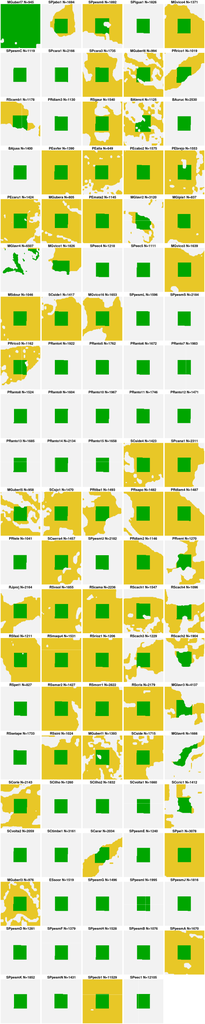

#### Janela de Código 4:

**Adequação do Raster** Códigos usados para aglomerar o habitat da comunidade local:

```r
v_Sites__conserto <- c("MGlavr6","MGlavr3")
df_auditoria2 <- df_auditoria %>% filter(SiteCode %in% v_Sites__conserto)
#########
par(mar=c(0.2,0.2,1.2,0.2))
i <- 2 #nrow = 5
N <- df_auditoria2$Ntotal[i]
paisagem <- as.matrix(read.table(df_auditoria2$txt.name[i],header = TRUE,sep = " ",as.is = FALSE))
# janela de observação:
d <- ceiling(sqrt(N)*(4/4))  # metade do lado do janela de observação
l <- ceiling(dim(paisagem)[1]/2) # linha central da paisagem
c <- ceiling(dim(paisagem)[2]/2) # coluna central da paisagem
# janela de observação:
janela_observao <- paisagem[(l-d):(l+d),(c-d):(c+d)]
###############################
########### região para remover
###############################
## objetos
#visualização
image(janela_observao,main=df_auditoria2$SiteCode[i],col=terrain.colors(12,rev = TRUE))
coordenada_ <- locator(1) %>% unlist()
l_ <- round(coordenada_[1]*nrow(janela_observao))
c_ <- round(coordenada_[2]*ncol(janela_observao))
n_ <- 10
## auditoria visual
image(janela_observao[(l_-n_):(l_+n_),(c_-n_):(c_+n_)],
      main=df_auditoria2$SiteCode[i],col=terrain.colors(12,rev = TRUE))
## para aqueles sem o habitat central como 1:
# janela_observao[(l_-n_):(l_+n_),(c_-n_):(c_+n_)] <- 2
## janela de conversao de 2->1
# Primeira vez
p_arrumar <- janela_observao[(l_-n_):(l_+n_),(c_-n_):(c_+n_)]
rm_ <- p_arrumar[p_arrumar==2] %>% length()
p_arrumar[p_arrumar==2] <- 1
janela_observao[(l_-n_):(l_+n_),(c_-n_):(c_+n_)] <- p_arrumar
# Outras vezes
p_arrumar <- janela_observao[(l_-n_):(l_+n_),(c_-n_):(c_+n_)]
rm_ <- rm_ + length(p_arrumar[p_arrumar==2])
p_arrumar[p_arrumar==2] <- 1
janela_observao[(l_-n_):(l_+n_),(c_-n_):(c_+n_)] <- p_arrumar
######################################
########### região para incluir 1 -> 2
######################################
##
image(janela_observao)
coordenada_ <- locator(1) %>% unlist()
l_ <- round(coordenada_[1]*nrow(janela_observao))
c_ <- round(coordenada_[2]*ncol(janela_observao))
n_ <- 2
janela_observao[(l_-n_):(l_+n_),(c_-n_):(c_+n_)] #  %>% image # habitat_local <-
# habitat_local[habitat_local==1] %>% length() > rm_
# para aqules com ponto central = 1
# janela_observao[l_+1,c_] <- 1
# exemplo: o ponto de inicío é [4,4] e o ponto l_,c_ é [3,3], portanto em termos de l_+1,c_+1:
p_inicio <- c(l_+1,c_+1)
# correr pela ___ até o ponto:
image(janela_observao)
coordenada_ <- locator(1) %>% unlist()
l_ <- round(coordenada_[1]*nrow(janela_observao))
c_ <- round(coordenada_[2]*ncol(janela_observao))
n_ <- 2
janela_observao[(l_-n_):(l_+n_),(c_-n_):(c_+n_)] # %>% image
p_final <- c(l_+1,c_)
# trocando 1 -> 2
p_rm_ <- janela_observao[p_inicio[1]:p_final[1],p_inicio[2]:p_final[2]] %>% length()
# if
p_rm_ < rm_
 janela_observao[p_inicio[1]:p_final[1],p_inicio[2]:p_final[2]] <- 2
 rm_ <- rm_ - p_rm_
# else
 janela_observao[p_inicio[1]:p_final[1],p_inicio[2]:p_final[2]][1:rm_] <- 2
## outro
# pontos_p_marcar <- janela_observao[p_inicio[1]:p_final[1],pwrite.table(paisagem,
            # file=df_auditoria2$txt.name[i],
# _inicio[2]:p_final[2]]
# pontos_p_marcar[pontos_p_marcar==1][1:length(rm_)] <- 2
# janela_observao[p_inicio[1]:p_final[1],p_inicio[2]:p_final[2]] <- pontos_p_marcar
# image(janela_observao)
# auditoria e gravar
par(mfrow=c(1,2))
image(paisagem[(l-d):(l+d),(c-d):(c+d)],
      main=paste(df_auditoria2$SiteCode[i], "before"),
      col=terrain.colors(12,rev = TRUE),axes=FALSE)
image(janela_observao,
      main=paste(df_auditoria2$SiteCode[i], "after"),
      col=terrain.colors(12,rev = TRUE),axes=FALSE)
paisagem[(l-d):(l+d),(c-d):(c+d)] <- janela_observao
par(mfrow=c(1,1))
image(paisagem,main=df_auditoria2$SiteCode[i],col=terrain.colors(12,rev = TRUE),axes=TRUE)
write.table(paisagem,
            file=df_auditoria2$txt.name[i],
            row.names = FALSE,col.names = FALSE)
```

#### Janela de Código 5:

Distância média de dispersão por k:

```r
## funções
library(rmutil)
library(lamW)
qkernel<- function(sigma, kernel, p, density=20852/50, npoints = 1e5){
    kernel <- match.arg(kernel, choices=c("normal","gaussian","laplace","uniform"))
    d_ind_MA  <- 100/sqrt(density)
    if(kernel=="laplace"){
        b_laplace <- sigma / sqrt(2)
        X_laplace <- d_ind_MA * round(rlaplace(npoints, s=b_laplace) / d_ind_MA)
        Y_laplace <- d_ind_MA * round(rlaplace(npoints, s=b_laplace) / d_ind_MA)
        dist_laplace <- sqrt(X_laplace^2+Y_laplace^2)
        result <- quantile(dist_laplace, p)
    }
    if(kernel=="normal"|kernel=="gaussian"){
        b_norm <- sigma
        X_norm <- d_ind_MA * round(rnorm(npoints, sd=b_norm) / d_ind_MA)
        Y_norm <- d_ind_MA * round(rnorm(npoints, sd=b_norm) / d_ind_MA)
        dist_norm <- sqrt(X_norm^2+Y_norm^2)
        result <- quantile(dist_norm, p)
    }
    if(kernel=="uniform"){
        b_unif <- sigma/2
        X_unif <- d_ind_MA * round(runif(npoints, min = -b_unif, max = b_unif) / d_ind_MA)
        Y_unif <- d_ind_MA * round(runif(npoints, min = -b_unif, max = b_unif) / d_ind_MA)
        dist_unif <- sqrt(X_unif^2+Y_unif^2)
        result <- quantile(dist_unif, p)
    }
    return(unname(result))
}
sigkernel <- function(kernel, p, distance, density=20852/50,
                      npoints =1e5, sigma.min = 1, sigma.max= 100){
    f1 <- function(x) distance - qkernel(x, kernel, p, density, npoints)
    uniroot( f1 , lower = sigma.min, upper = sigma.max)
}
## estimativa
# dados
df_auditoria %<>% filter(SiteCode != "MGlavr4")
percentil <- c(0.99,seq(0.95,0.05,-0.05))
df_simulacao <- left_join(x=df_auditoria,
                          y=expand.grid(SiteCode = df_auditoria$SiteCode, k = percentil),
                          by="SiteCode")

df_simulacao$kernel_type <- "laplace"
df_simulacao$kernel_code <- "2"
df_simulacao %<>% mutate(DA=Ntotal/effort_ha, # densidade desconsiderando as espécies mortas
                         dist_0 = 100/sqrt(DA)) # distância entre indivíduos vizinhos
df_simulacao$d <- NA
df_simulacao$kernel_type <- as.character(df_simulacao$kernel_type)
# funcao para paralelizar
func_llply <- function(i,data_frame=df_simulacao){
  df_temp <- data_frame
  sigma <- sigkernel(kernel = df_temp[i,"kernel_type"],
                     p = df_temp[i,"k"],
                     distance = df_temp[i,"dist_0"],
                     density = df_temp[i,"DA"],
                     sigma.min=1e-6,
                     sigma.max=1e6)$root
}
registerDoMC(3)
replica.sim <- as.list(1:dim(df_simulacao)[1])
resultados <- llply(.data = replica.sim, .fun = func_llply, .parallel = TRUE)
df_simulacao$d <- unlist(resultados)
```

#### Janela de Código 6:

Cálculo da proporção de habitat na paisagem (p):

```r
f_tree.cover <- function(file_path){
  mat_paisagem <- read.table(file=file_path,sep=" ",header=TRUE)
  tree.cover <- as.vector(mat_paisagem)
  tree.cover <- tree.cover[!is.na(tree.cover)]
  p <- 1 - length(tree.cover[tree.cover==0])/length(tree.cover)
  return(p)
}
df_ <- df_simulacao %>% select(SiteCode,txt.name) %>% distinct()
registerDoMC(3)
df_$p <- aaply(df_$txt.name,1,f_tree.cover,.parallel = TRUE)
df_simulacao <- left_join(x = df_simulacao,
                          y = select(df_,-txt.name),
                          by="SiteCode")
```

#### Janela de Código 7:

função para rodar a simulação coalescente

```r
dinamica_coalescente <- function(U, S=0, N_simul, seed, disp_range, disp_kernel, landscape){
  # Runs coalescent simulations for a given heterogeneous landscape
  #
  # Parameters:
  # U: speciation rate
  # S: observed richness (integer) - used to fit the value of U, or set to
  #       0 (default) if that is not desired
  # N_simul: number of simulations
  # seed: seed of the RNG (an integer)
  # disp_range: width of the dispersal kernel
  # disp_kernel: an integer corresponding to the type of dispersal kernel. One of
  #               0: uniform
  #               1: normal
  #               2: Laplacian
  # landscape: either a filename containing the landscape data, or a
  #   bidimensional R array or matrix.
  #   TODO: describe the format of the input - trinary matrix)
  #
  # Returns:
  # r: an array of dimension N_simul x landscape dimensions, that is, each
  #   r[i.,] is a bidimensional array of the same shape as the landscape.
  #   Each site is labeled according to the identity of the species occupying
  #   that site.
  # U_est: estimated speciation rate. This is returned only if input parameter S > 0
  if (is.character(landscape)){
    l <- as.matrix(read.table(landscape))
    infile <- landscape
    land_dims <- dim(l)
  } else {
    land_dims <- dim(landscape)
    infile <- tempfile()
    # input file *must* be clean: no comments, headers or anything
    write.table(landscape, infile, col.names=F, row.names=F)
  }
  outfile <- tempfile()
  repeat {
    system(paste('./dinamica_coalescente', land_dims[1], land_dims[2], U, S, N_simul,
                 seed, disp_range, disp_kernel, infile, outfile))
    if (file.exists(outfile) || S == 0)
      break
    U <- U/10.
    print(paste("Decreasing value of U to", U))
    # set some lowest boundary here so simulations don't take forever
    if (U < 1e-20){
      print("Richness value too low, giving up...")
      return(NULL)
    }
  }
  r <- as.matrix(read.table(outfile))
  # transpose each grid, as output is written along lines but R reads it along columns
  # TODO: I thought I got it right, but it was wrong... please DO re-check
  #r <- aperm(r, c(1,3,2))

  # recover estimated speciation rate
  if (S > 0){
    out_con <- file(outfile)
    U_line <- strsplit(readLines(out_con, 2)[2], ' ')[[1]]
    close(out_con)
    U_est <- as.double(U_line[length(U_line)])
    return(list(r = r, U_est = U_est))
  }
  return(r)
}
```

#### Janela de Código 8:

Estimativa de U

```r
# replicas
n_rep.U <- 10
func1 <- function(x,replicas=n_rep.U) {
  x$U <- NA
  x <- x[rep(1:dim(x)[1],each=replicas),]
}
df_simulacao$txt.name <- gsub("dados_brutos","simulacao",df_simulacao$txt.name)
df_simulacao.U <- df_simulacao %>% func1()
# simulacao
# valores de k
k_factor <- unique(df_simulacao.U$k)
registerDoMC(3)
for(a in 1:length(k_factor)){
  df_simU <- df_simulacao.U %>% dplyr::filter(k == k_factor[a])
  op <- options(digits.secs=6)
  funcao_imigracao <- function(i,df_temp=df_simU){
    aviao <- list()
    aviao <- dinamica_coalescente(U = 1.25e-06,
                                  S = df_temp[i,"S_obs"],
                                  N_simul = 1,
                                  seed = as.numeric(Sys.time()),
                                  disp_range = df_temp[i,"d"],
                                  disp_kernel = df_temp[i,"kernel_code"],
                                  landscape = df_temp[i,"txt.name"])
    return(aviao$U_est)
  }
  replica.sim <- as.list(1:dim(df_simU)[1])
  sim.coal_U <- llply(.data = replica.sim, .fun = funcao_imigracao, .parallel = TRUE)
  df_simU[,"U"] <- unlist(sim.coal_U)
  write.csv(df_simU,
            file=paste0("./U/","df_simU__k",k_factor[a],".csv"),row.names = FALSE)
}
```

#### Janela de Código 9:

Conversão de Parâmetros:

```r
# Síntese dos dados para U
df_U <- map_df(Sys.glob("~/Documentos/Doutorado/artigo_mestrado/1A.P_MOVER/simulacao/U/*.csv"), read_csv)
df_simulacao <-  inner_join(x=distinct(dplyr::select(df_U, SiteCode, k, Ntotal, S_obs, kernel_code, DA, d, p, txt.name)),
                            y=ddply(df_U,c("SiteCode","k"),summarise,U_med = mean(U), U_var = var(U)),
                            by=c("SiteCode","k"))
# conversão de parâmetros
df_simulacao %<>%
  mutate(J_M = 10404 * DA * p,
         L_plot = sqrt( 10000 * (Ntotal/DA) ),
         m = d * (1 - exp( -sqrt(2) * (L_plot/d) ) ) / ( sqrt(2) * L_plot ), #eq 4
         m_ = m * p / ( 1 - (1-p)*m ),#eq 5
         I =  m_ * (Ntotal-1)/(1-m_), #Etienne 2005
         theta = U_med * ( J_M - 1 ) / (1-U_med) ) #Vallade & Houshmandzadeh (2003)
n_rep.SAD <- 100
```

#### Figura 3:

Gráficos Exploratórios dos parâmetros dos modelos neutros:

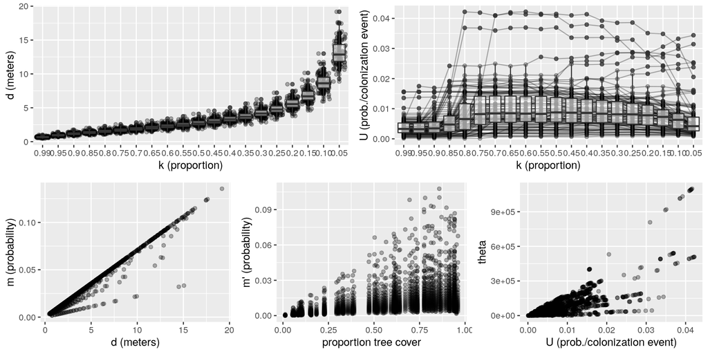

#### Janela de Código 10:

SAD predita MNEE:

```r
f_simulacao <- function(i,df_=df_simulacao){
  X <- df_[i,] %>% as.data.frame()
  mat_sim <- dinamica_coalescente(U = X[,"U_med"],
                                  S = 0,
                                  N_simul = n_rep.SAD,
                                  seed = as.numeric(Sys.time()),
                                  disp_range = X[,"d"],
                                  disp_kernel = X[,"kernel_code"],
                                  landscape = X[,"txt.name"])
  df_SAD.replica <- bind_rows(alply(mat_sim,1,function(Y) data.frame(N = sort(as.integer(table(Y))) ) ),
                              .id = "replica")
  df_SAD.replica %<>%
    mutate(SiteCode = X$SiteCode, MN = "EE", k = X$k)
  path.file <- paste0("/home/danilo/Documentos/Doutorado/artigo_mestrado/1A.P_MOVER/simulacao/SADs_preditas/",
                      X[,"SiteCode"],
                      "_k",X[,"k"],
                      "_EE.csv")
  write.csv(df_SAD.replica,
            file = path.file,
            row.names = FALSE)
}
registerDoMC(3)
simulacao <- as.list(1:dim(df_simulacao)[1])
l_ply(simulacao,f_simulacao,.parallel = TRUE)
```

#### Janela de Código 11:

SAD predita MNEI:

```r
# simulação
f_Etienne <- function(theta_,I_,J_){
  df_ <- data.frame(N=generate.ESF(theta=theta_,I=I_,J=J_))
}
f_simulacaoEI <- function(i,df_=df_simulacao){
  # i <- 1
  # n_rep.SAD <- 100
  df_name <- df_[i,] %>% as.data.frame
  df_SAD.replica <- bind_rows(rerun(.n=n_rep.SAD,f_Etienne(theta_ = df_name$theta, I_ = df_name$I, J_ = df_name$Ntotal)),
                      .id="replica")
  df_SAD.replica %<>%
    mutate(SiteCode = df_name$SiteCode, MN = "EI", k = df_name$k)
  path.file <- paste0("/home/danilo/Documentos/Doutorado/artigo_mestrado/1A.P_MOVER/simulacao/SADs_preditas/",
                      df_name[,"SiteCode"],
                      "_k",df_name[,"k"],
                      "_EI.csv")
  write.csv(df_SAD.replica,
            file = path.file,
            row.names = FALSE)
  }
registerDoMC(3)
simulacao <- as.list(1:dim(df_simulacao)[1])
l_ply(simulacao,f_simulacaoEI,.parallel = TRUE)
```

#### Janela de Código 12:

Comparação das SAD pelo teste KS bootstrap:

```r
### rotina
df_resultados$resultados <- vector("list",length = nrow(df_resultados))
registerDoMC(3)
for(i in 1:nrow(df_resultados)){
  X <- df_resultados[i,]
  v_SADobs <- X$SAD_obs[[1]]$N
  f_KS <- function(v_obs=v_SADobs,v_MN,boots=300){
    testeKS <- ks_test(a=v_obs,b = v_MN, nboots = boots)
    a <- data.frame(D_KSboot=testeKS[1],p.valor_KSboot=testeKS[2])
    a$S_SAD.predita <- length(v_MN)
    a$S_SAD.obs <- length(v_obs)
    return(a)
  }
  df_predicao <- X$SAD_MN[[1]] %>% as.data.frame()
  f_resultados <- function(path_df,parallel_=FALSE){
    # path_df <- df_predicao$file_path[27]
    df_SAD.MN <- read.csv(path_df,header = TRUE,as.is = TRUE)
    df_return <- ddply(df_SAD.MN,"replica",function(Y) f_KS(v_MN=Y$N),.parallel = parallel_)
    df_return %<>% mutate(SiteCode = df_SAD.MN$SiteCode[1],
                          MN = df_SAD.MN$MN[1],
                          k = df_SAD.MN$k[1])
    return(df_return)
  }
  df_resultados$resultados[[i]] <- adply(df_predicao,1,
                       function(line) f_resultados(path_df = line$file_path),.parallel = TRUE)
}
for(i in 1:nrow(df_resultados)){
  df_resultados$resultados[[i]]$replica <- as.character(df_resultados$resultados[[i]]$replica)
}
df_replicas <- df_resultados %>% rename(Site = SiteCode) %>%
  select(resultados) %>% unnest(cols=c(resultados)) %>% as.data.frame() %>%
  select(SiteCode,MN,k,replica,D_KSboot,p.valor_KSboot,S_SAD.predita,S_SAD.obs)
write.csv(df_replicas,
          file="/home/danilo/Documentos/Doutorado/artigo_mestrado/1A.P_MOVER/simulacao/resultados/df_replicas.csv",
          row.names = FALSE)
```

#### Figura 4:

Avaliação da auto-coerência do teste KS bootstrap por replica:

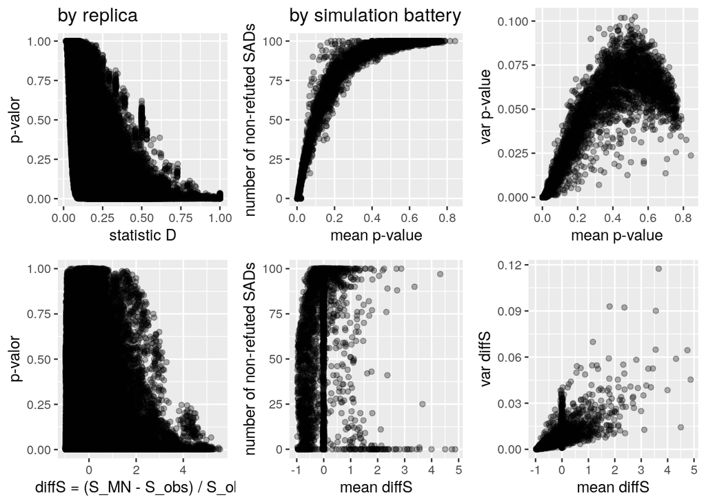